# Practice Machine Learning

Data Science Specialization

Javier Gonzalez <javier.gonzalez.grandez@gmail.com

12 de junio de 2018

# 1 Background

Using devices such as Jawbone Up, Nike FuelBand, and Fitbit it is now possible to collect a large amount of data about personal activity relatively inexpensively. These type of devices are part of the quantified self movement – a group of enthusiasts who take measurements about themselves regularly to improve their health, to find patterns in their behavior, or because they are tech geeks. One thing that people regularly do is quantify how much of a particular activity they do, but they rarely quantify how well they do it. In this project, your goal will be to use data from accelerometers on the belt, forearm, arm, and dumbbell of 6 participants. They were asked to perform barbell lifts correctly and incorrectly in 5 different ways.

# 2 Environment

This is the environment required to execute the process, we assume this document and datasets are in the same working directory and original datasets are called:

- pml-training.csv
- pml-testing.csv

otherwise you must adjust this piece of code.

```r
library(caret)
library(e1071)
library(randomForest)

ds.training = 'pml-training.csv'
ds.testing  = 'pml-testing.csv'
# Minimum percentage of NAs in a column to remove
MIN.NA <- .75

setwd('P:/R/PML')  # Set the current environment
```

# 3 Approach

Our method to implement this machine is:

1. Load the data and analyse to clean it up
2. Identify relevant features and covariates, confounders, etc.
3. Apply different models to identify which one provides more accuracy
4. Improve the model chosen til get an enough accuracy
5. Apply the model to test data

# 4 Cleaning up

## 4.1 Loading data

```r
# First load of file
pml.base = read.csv(ds.training)
# head(pml.base)   # Omitted for HTML page
dim(pml.base)
```

```
## [1] 19622   160
```

Making this primer load of data we can see a lot of features as well as many missing or inconsistent values, mainly in the form of empty values but also as NA and DIV/0.

So, in order to capture these values as NA we need to extend the na.string parameter

```r
NAS=c("", "NA", "#DIV/0!")
pml.base = read.csv('pml-training.csv', na.string=NAS)
prc.na = sum(is.na(pml.base)) / prod(dim(pml.base)) # check number of NA
```

Number of rows: **19622**

Number of columns: **160**

Percentage of missing values: **61.3183544**

## 4.2 Removing features

To remove a part of these NA values we start removing features with an amount of NA values over an specific threshold.

This threshold is stored into MIN.NA variable (see Environment):

```r
# Calculate number of NA by column
prc.na <- colSums(sapply(pml.base, is.na)) / nrow(pml.base)

# Remove columns
cols.ignore <- names(prc.na[prc.na > MIN.NA])
pml.work <- pml.base[ , !(names(pml.base) %in% cols.ignore)]
prc.na <- sum(is.na(pml.work)) / prod(dim(pml.work))
```

Number of columns: **60**

Percentage of missing values: **0**

Great! We have removed all NA values and reduce significativally the number of features. That is, all these values are contained in some columns not along records and features.

## 4.3 Removing columns not useful for training

There is not a code-book of dataset, so we have no information about all columns into dataset, but we know that:

- **X** Is an unique identifier
- **user** Is the name of user
- **timestamps** Are not relevant because we don’t analyse the timeline

We remove these columns to reduce the size of dataset and create the base dataset for training the models.

```r
pml.base = pml.work[, -c(1:6)]
```

# 5 Model Selection

1. Support Vector Machine
2. Random Forest
3. K-nearest neighbors

For train dataset we’ll use the 75% of data

```r
v.train <- createDataPartition(pml.base$classe, p = 0.75, list = FALSE)
pml.train <- pml.base[v.train,]
pml.test  <- pml.base[-v.train,]
```

## 5.1 Model 1: Support Vector Machine

```r
model.svm <- svm(classe~., data = pml.train)
pred.svm <- predict(model.svm, newdata = pml.test)
cm.svm = confusionMatrix(pred.svm, pml.test$classe)
```

## 5.2 Model 2: Random Forest

```r
model.rf <- randomForest(classe~., data = pml.train, n.trees = 500)
pred.rf <- predict(model.rf, newdata = pml.test)
cm.rf = confusionMatrix(pred.rf, pml.test$classe)
```

## 5.3 Model 3: K-nearest neighbors

```r
train.ctrl <- trainControl(method = "boot632", number = 5)
model.knn <- train(classe~., data = pml.train, method = "knn",
                  trControl = train.ctrl,
                  preProcess = c("center", "scale"),
                  tuneLength = 10)
pred.knn <- predict (model.knn, newdata = pml.test)
cm.knn = confusionMatrix(pred.knn, pml.test$classe)
```

## 5.4 Results

```r
df.res = rbind(cm.svm$overall, cm.rf$overall, cm.knn$overall)
df.res = cbind(c("SVM", "RF", "KNN"), df.res)
print(df.res[,c(1,2,4,5)])
```

```
##            Accuracy            AccuracyLower       AccuracyUpper
## [1,] "SVM" "0.945962479608483" "0.939262317891867" "0.952125239757218"
## [2,] "RF"  "0.997145187601958" "0.99521474437818"  "0.998438395828971"
## [3,] "KNN" "0.969004893964111" "0.963764698215497" "0.973676398635343"
```

### 5.4.1 Random Forest - Confussion Matrix

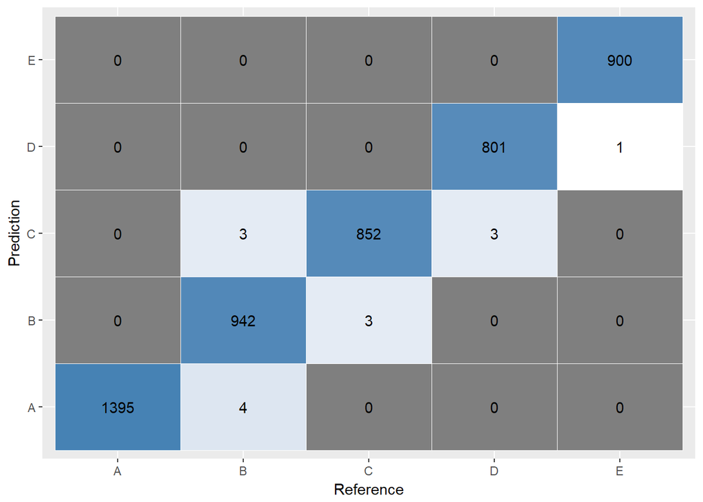

### 5.4.2 Random Forest - Sensitivity

```
##          Sensitivity Specificity Balanced Accuracy
## Class: A   1.0000000   0.9988601         0.9994300
## Class: B   0.9926238   0.9992415         0.9959326
## Class: C   0.9964912   0.9985182         0.9975047
## Class: D   0.9962687   0.9997561         0.9980124
## Class: E   0.9988901   1.0000000         0.9994451
```

# 6 Prediction

Using the Random Forest model for predict the test cases, the result is:

```r
# Create pml.test according pml.train
pml.test.base =  read.csv(ds.testing, na.string=NAS)
pml.test =  pml.test.base[ , names(pml.test.base) %in% colnames(pml.train)]
pred.test <- predict(model.rf, newdata = pml.test)
print(pred.test)
```

```
##  1  2  3  4  5  6  7  8  9 10 11 12 13 14 15 16 17 18 19 20
##  B  A  B  A  A  E  D  B  A  A  B  C  B  A  E  E  A  B  B  B
## Levels: A B C D E
```